# Lesson 1

Lukasz Piszczek, Kaja Moczulska

2025-10-10

# Load Data

Purpose: Load Alzheimer’s gene expression data and metadata; clean and reshape for analysis.

Here we will work on Alzheimers data: Microarray analysis of postmortem human brains with presence or absence of Alzheimer’s disease

**Format** A tibble with gene expression, brain regions, patient data. **Source** Data taken from https://europepmc.org/article/MED/23595620 https://www.ebi.ac.uk/gxa/experiments/E-GEOD-36980/Downloads

```r
# Select genes of interest for analysis (defined by biological relevance or prior studies).
genes <- c(
  "MET", "PCSK1", "RGS4", "HS3ST2", "NPTX2", "NEUROD6",
  "RAB27B", "IL12RB2", "FAM19A1", "HCN1", "GABRA1", "KIAA1045", "PRKCB", "HPCA", "PTPN3", "SERPINF1",
  "WIPF3", "GFRA2", "HS6ST3", "PARM1", "NUAK1", "NRN1", "VEGFA", "ENC1", "RAB15", "SATB1", "PHACTR1",
  "ANO3", "HOPX", "ELAVL4", "CPLX1", "C14orf83", "EHD3", "KIAA0746", "LINGO1", "KCNK9", "ACOT7", "MSC",
  "PDE2A", "HCN2", "FABP3", "SLC6A7", "RGS7", "WBSCR17", "ATP2B2", "NEFH", "RIT2", "EGR3", "GNG3",
  "NPTXR", "ARHGDIG", "CCKBR", "ST8SIA5", "SLC6A17", "ATRNL1", "LDB2", "SYT13", "SMYD2",
  "MAN1A1", "GABRG2", "STMN2", "L1CAM", "C12orf5", "HOMER1", "SYT7", "TRIM36", "EFNA3", "DLGAP1",
  "GABBR2", "FRMPD4", "RIMBP2", "INA", "AACS", "STRBP", "CHRNB2", "ATP2B3", "TTYH3", "RTN4RL1",
  "SYT5", "GABRA4", "DAGLA", "CDH22", "SEZ6L2", "SLC17A7", "NEFL", "OXR1", "ADAM11",
  "LIPH", "NAP1L2", "SYNGR3", "TOM1L1", "KCNJ6", "UQCRH", "STX1B", "GABRA5", "ACOT8", "ORAI2",
  "SNAP25", "WBSCR17", "PPP1R16B", "TOLLIP", "LARGE", "GLRB", "PTPRN", "SYT4", "DUSP6", "DOC2A",
  "SPTBN2", "NEDD4L", "POPDC3", "SYN1", "PREP", "MMP17",
  "QPCT", "CPT1C", "NDFIP2", "ARL15", "DPF1", "HPRT1", "ATP6V1G2", "SH3RF1", "KCNF1", "PTPN5",
  "MAPK9", "PFKP", "PTPRN2", "TLN2", "GDAP1L1", "ISLR2", "ADAP1", "C3orf14", "TSPAN5", "APBA2",
  "RNF165", "SLC7A14", "TOMM22", "FNDC5", "YWHAG", "KRT222",
  "SLC7A11", "GOLIM4",
  "HSD17B7P2", "LAMA4",
  "IFLTD1", "PCDHB4", "COL21A1", "CNGA3", "FAM36A",
  "EGF", "FAP", "FIBIN", "SNTB1", "TAS2R31",
  "CA5B", "NCRNA00173",
  "SSPN",
  "ANGPT1", "B3GAT2", "VCAN", "GJA1", "VCAM1",
  "ST6GALNAC2", "TXNIP", "ARRDC4", "WDR49", "AEBP1", "PIRT", "GALNTL2"
)
# Optionally: select a smaller subset for focused analysis.
test_genes <- c("MET", "PCSK1", "PTPN3", "SERPINF1", "VEGFA", "NEFH", "EGR3", "HOMER1", "INA", "DAGLA",
  "CDH22", "NEFL", "TOM1L1", "TOLLIP", "SH3RF1", "TOMM22", "AEBP1", "TXNIP", "VCAM1", "ANGPT1",
  "RGS4", "GABRA1", "GFRA2", "CPLX1", "KCNK9", "RGS7", "GABRG2", "STMN2", "L1CAM", "SYT7",
  "SYT5", "GABRA4", "KCNJ6", "STX1B", "GABRA5", "SNAP25", "PTPRN", "SYT4", "DUSP6", "PTPN5",
  "PTPRN2", "IL12RB2", "PRKCB", "WIPF3", "NRN1", "ENC1", "SATB1", "PHACTR1", "ELAVL4", "FABP3",
  "AACS", "SPTBN2", "YWHAG")

# Read normalized gene expression table. Drop unneeded columns; keep gene names.
df <- read_delim(file = "./Input_data/E-GEOD-36980-A-AFFY-141-normalized-expressions.tsv") %>%
  select(-`Gene ID`, -DesignElementAccession) %>%      # Remove Gene ID columns as not needed
  rename(Gene = `Gene Name`) %>%                       # Rename for clarity
  pivot_longer(cols = starts_with("GSM"),              # Reshape: aim is to have one row per patient
    names_to = "Assay", values_to = "Gene_expression") %>%
  pivot_wider(names_from = Gene, values_from = Gene_expression, values_fn = mean) %>%
  dplyr::select(Assay, any_of(genes))                  # Keep only selected genes
df_meta <- read_delim(file = "./Input_data/E-GEOD-36980-experiment-design.tsv") %>%
  dplyr::select(Assay, `Sample Characteristic[disease]`, `Sample Characteristic[sex]`, `Sample Characteristic[organism part]`) %>%
  rename(Class = `Sample Characteristic[disease]`, # Rename for readability
         sex = `Sample Characteristic[sex]`,
         Brain_Area = `Sample Characteristic[organism part]`) %>%
  mutate(Class = factor(Class), # Convert to categorical
         sex = factor(sex),
         Brain_Area = factor(Brain_Area))
# Merge gene expression and metadata on assay ID to create full analysis table.
df <- df %>% left_join(df_meta, ., by = "Assay") #%>% filter(Brain_Area == "hippocampus")
```

##Get basic information about the data frame

```r
# Show dimensions of data frame
dim(df)
```

```
## [1]  79 154
```

how many rows is there? how many columns are there?

```r
# check what the output means
?dim
```

```r
# Show number of rows
nrow(df)
```

```
## [1] 79
```

```r
# Show number of columns
ncol(df)
```

```
## [1] 154
```

```r
# Show first (here 20) entries
head(df, 20)
```

```
## # A tibble: 20 × 154
##    Assay    Class sex   Brain_Area   MET PCSK1  RGS4 HS3ST2 NPTX2 NEUROD6 RAB27B
##    <chr>    <fct> <fct> <fct>      <dbl> <dbl> <dbl>  <dbl> <dbl>   <dbl>  <dbl>
##  1 GSM9077… Alzh… male  frontal c…  8.29  9.80  12.1   9.09  8.95    8.38  10.1
##  2 GSM9077… Alzh… fema… frontal c…  7.30  9.65  11.9   9.36  9.11    8.41   9.58
##  3 GSM9077… Alzh… fema… frontal c…  8.34  9.71  11.9   9.04  8.65    8.30   9.94
##  4 GSM9077… Alzh… male  frontal c…  7.80  9.75  11.8   9.22  9.03    8.23   9.76
##  5 GSM9077… Alzh… fema… frontal c…  7.48  9.21  11.7   9.03  8.43    7.64   9.92
##  6 GSM9077… Alzh… fema… frontal c…  8.15  6.42  10.5   8.21  8.63    6.79   8.98
##  7 GSM9077… Alzh… fema… frontal c…  7.76  9.38  11.7   9.22  8.78    8.27   9.41
##  8 GSM9077… Alzh… fema… frontal c…  7.74  9.83  11.8   9.17  8.64    8.48  10.2
##  9 GSM9078… Alzh… fema… frontal c…  8.26  9.62  11.9   8.75  8.64    8.79   9.99
## 10 GSM9078… Alzh… male  frontal c…  8.04  9.69  12.0   9.05  8.59    8.36   9.91
## 11 GSM9078… Alzh… male  frontal c…  8.35  8.84  12.1   8.01  9.13    7.71   9.66
## 12 GSM9078… Alzh… fema… frontal c…  7.56  9.88  12.0   8.86  8.40    8.38   9.97
## 13 GSM9078… Alzh… male  frontal c…  8.23 10.4   12.2   9.11  9.05    8.67  10.3
## 14 GSM9078… Alzh… male  frontal c…  8.33  9.96  12.3   9.00  9.12    8.11   9.86
## 15 GSM9078… Alzh… male  frontal c…  8.06 10.0   12.1   8.87  8.98    8.64  10.1
## 16 GSM9078… norm… male  frontal c…  8.03  9.83  12.1   8.90  8.80    8.57   9.97
## 17 GSM9078… norm… fema… frontal c…  7.89  9.34  11.9   8.98  8.83    8.25   9.77
## 18 GSM9078… norm… fema… frontal c…  8.18 10.2   12.1   9.77  9.84    8.19   9.97
## 19 GSM9078… norm… fema… frontal c…  8.10 10.1   11.9   9.28  8.46    8.10  10.0
## 20 GSM9078… norm… fema… frontal c…  7.66  9.59  11.8   8.95  8.75    8.25  10.4
## # ℹ 143 more variables: IL12RB2 <dbl>, HCN1 <dbl>, GABRA1 <dbl>, PRKCB <dbl>,
## #   HPCA <dbl>, PTPN3 <dbl>, SERPINF1 <dbl>, WIPF3 <dbl>, GFRA2 <dbl>,
## #   HS6ST3 <dbl>, PARM1 <dbl>, NUAK1 <dbl>, NRN1 <dbl>, VEGFA <dbl>,
## #   ENC1 <dbl>, RAB15 <dbl>, SATB1 <dbl>, PHACTR1 <dbl>, ANO3 <dbl>,
## #   HOPX <dbl>, ELAVL4 <dbl>, CPLX1 <dbl>, EHD3 <dbl>, LINGO1 <dbl>,
## #   KCNK9 <dbl>, ACOT7 <dbl>, MSC <dbl>, PDE2A <dbl>, HCN2 <dbl>, FABP3 <dbl>,
## #   SLC6A7 <dbl>, RGS7 <dbl>, ATP2B2 <dbl>, NEFH <dbl>, RIT2 <dbl>, …
```

```r
# Show last (here 20) entries
tail(df, 20)
```

```
## # A tibble: 20 × 154
##    Assay    Class sex   Brain_Area   MET PCSK1  RGS4 HS3ST2 NPTX2 NEUROD6 RAB27B
##    <chr>    <fct> <fct> <fct>      <dbl> <dbl> <dbl>  <dbl> <dbl>   <dbl>  <dbl>
##  1 GSM9078… norm… male  temporal …  9.19  8.99 11.9    9.18  9.36    8.50  10.8
##  2 GSM9078… norm… fema… temporal …  8.50  9.08 12.1    8.85  9.24    8.23  10.7
##  3 GSM9078… norm… fema… temporal …  9.19  8.25 12.2    8.29  9.86    8.21   9.93
##  4 GSM9078… Alzh… fema… hippocamp…  7.93  8.42 11.4    8.97  8.61    8.19  10.1
##  5 GSM9078… Alzh… fema… hippocamp…  7.68  7.86 10.5    8.30  9.05    7.91   9.50
##  6 GSM9078… Alzh… fema… hippocamp…  7.42  7.01 10.1    8.19  8.41    7.67   9.10
##  7 GSM9078… Alzh… fema… hippocamp…  6.03  6.30  8.32   8.12  8.85    7.15   7.78
##  8 GSM9078… Alzh… male  hippocamp…  6.10  7.65  9.93   7.94  8.89    6.60  10.00
##  9 GSM9078… Alzh… male  hippocamp…  7.49  9.45 12.1    9.12  9.36    8.49  10.6
## 10 GSM9078… Alzh… male  hippocamp…  7.09  8.51 10.4    8.28  8.59    7.82  10.4
## 11 GSM9078… norm… fema… hippocamp…  7.55  9.14 11.8    9.25  9.45    8.96  10.6
## 12 GSM9078… norm… fema… hippocamp…  9.28  9.31 11.6    9.04  9.85    9.60  10.4
## 13 GSM9078… norm… fema… hippocamp…  8.10  9.32 11.8    9.05  9.03    9.01  10.7
## 14 GSM9078… norm… male  hippocamp…  9.66  9.98 12.1    8.97 10.5     9.27  11.0
## 15 GSM9078… norm… male  hippocamp…  9.04  9.66 12.0    9.09 10.2     9.26  11.0
## 16 GSM9078… norm… fema… hippocamp…  9.18 10.2  11.3   10.7  11.0     7.88  10.3
## 17 GSM9078… norm… fema… hippocamp…  8.64  8.94 11.6    9.11  9.14    9.22  10.7
## 18 GSM9078… norm… male  hippocamp…  7.79  8.55 11.1    8.85  9.61    8.74  10.8
## 19 GSM9078… norm… male  hippocamp…  8.18  8.89 11.9    9.14 10.7     8.06  10.6
## 20 GSM9078… norm… male  hippocamp…  9.19  9.30 11.9    8.85  9.48    8.62  11.1
## # ℹ 143 more variables: IL12RB2 <dbl>, HCN1 <dbl>, GABRA1 <dbl>, PRKCB <dbl>,
## #   HPCA <dbl>, PTPN3 <dbl>, SERPINF1 <dbl>, WIPF3 <dbl>, GFRA2 <dbl>,
## #   HS6ST3 <dbl>, PARM1 <dbl>, NUAK1 <dbl>, NRN1 <dbl>, VEGFA <dbl>,
## #   ENC1 <dbl>, RAB15 <dbl>, SATB1 <dbl>, PHACTR1 <dbl>, ANO3 <dbl>,
## #   HOPX <dbl>, ELAVL4 <dbl>, CPLX1 <dbl>, EHD3 <dbl>, LINGO1 <dbl>,
## #   KCNK9 <dbl>, ACOT7 <dbl>, MSC <dbl>, PDE2A <dbl>, HCN2 <dbl>, FABP3 <dbl>,
## #   SLC6A7 <dbl>, RGS7 <dbl>, ATP2B2 <dbl>, NEFH <dbl>, RIT2 <dbl>, …
```

## Ivestigate the data structure

Lets investigate the data set

```r
# Show structure of the main data frame (column types, dimensions).
str(df)
```

```
## tibble [79 × 154] (S3: tbl_df/tbl/data.frame)
##  $ Assay     : chr [1:79] "GSM907792" "GSM907793" "GSM907794" "GSM907795" ...
##  $ Class     : Factor w/ 2 levels "Alzheimers disease",..: 1 1 1 1 1 1 1 1 1 1 ...
##  $ sex       : Factor w/ 2 levels "female","male": 2 1 1 2 1 1 1 1 1 2 ...
##  $ Brain_Area: Factor w/ 3 levels "frontal cortex",..: 1 1 1 1 1 1 1 1 1 1 ...
##  $ MET       : num [1:79] 8.29 7.3 8.34 7.8 7.48 ...
##  $ PCSK1     : num [1:79] 9.8 9.65 9.71 9.75 9.21 ...
##  $ RGS4      : num [1:79] 12.1 11.9 11.9 11.8 11.7 ...
##  $ HS3ST2    : num [1:79] 9.09 9.36 9.04 9.22 9.03 ...
##  $ NPTX2     : num [1:79] 8.95 9.11 8.65 9.03 8.43 ...
##  $ NEUROD6   : num [1:79] 8.38 8.41 8.3 8.23 7.64 ...
##  $ RAB27B    : num [1:79] 10.07 9.58 9.94 9.76 9.92 ...
##  $ IL12RB2   : num [1:79] 8.05 7.68 7.85 8.01 7.82 ...
##  $ HCN1      : num [1:79] 11.5 10.8 11.5 11.2 11.4 ...
##  $ GABRA1    : num [1:79] 11.9 11.4 11.9 11.7 11.7 ...
```

[output cut: 86 more lines]

## get numeric vectors to compare

```r
# choose a gene and save the expression data of this gene separately for AD and control patients
gene_name <- 'NPTX2'

normal_expr <-
    df %>%
      filter(Class == 'normal') %>%
      pull(gene_name)

ad_expr <-
    df %>%
      filter(Class == 'Alzheimers disease') %>%
      pull(gene_name)
print(normal_expr)
```

```
##  [1]  8.800390  8.832480  9.843439  8.462419  8.754060  9.984896  9.277159
##  [8]  9.511013 10.908672  9.564304  9.770501  8.821624  8.891444  8.895829
## [15] 11.125804  9.304109  8.946388  8.558751  9.235973 10.405794  9.492565
## [22]  9.356452  9.933042 10.175226 10.634883  9.398559  9.890596 10.344369
## [29]  9.190865 10.047150 10.004380  9.195267 10.528948  9.978302  9.361686
## [36]  9.243759  9.861516  9.448177  9.848605  9.033672 10.492372 10.193051
## [43] 10.987176  9.136215  9.611950 10.670219  9.481564
```

```r
print(ad_expr)
```

```
##  [1]  8.949048  9.106863  8.651043  9.027170  8.431660  8.628765  8.780061
##  [8]  8.638264  8.641575  8.591918  9.131464  8.402498  9.048373  9.115655
## [15]  8.977896  8.704842  9.068634  9.183321  9.420054  8.543458  8.790353
## [22]  8.541078 10.065213  9.567140  8.353973  8.606634  9.046450  8.407463
## [29]  8.846671  8.885010  9.358940  8.592559
```

## basic statistics

```r
# calculate mean
mean_n = mean(normal_expr)
mean_ad = mean(ad_expr)
print (mean_n)
```

```
## [1] 9.647566
```

```r
print (mean_ad)
```

```
## [1] 8.878251
```

```r
# calculate median
median_n = median(normal_expr)
median_ad = median(ad_expr)
print (median_n)
```

```
## [1] 9.511013
```

```r
print (median_ad)
```

```
## [1] 8.818512
```

```r
# test difference between means (t-test)
t.test(normal_expr, ad_expr)
```

```
##
##  Welch Two Sample t-test
##
## data:  normal_expr and ad_expr
## t = 6.4976, df = 74.933, p-value = 8.016e-09
## alternative hypothesis: true difference in means is not equal to 0
## 95 percent confidence interval:
##  0.5334464 1.0051832
## sample estimates:
## mean of x mean of y
##  9.647566  8.878251
```

```r
# test difference between medians (wilcox-test
wilcox.test(normal_expr, ad_expr)
```

```
##
##  Wilcoxon rank sum exact test
##
## data:  normal_expr and ad_expr
## W = 1271, p-value = 3.924e-08
## alternative hypothesis: true location shift is not equal to 0
```

## intro to visual analytics

#assess the data distribution using histograms

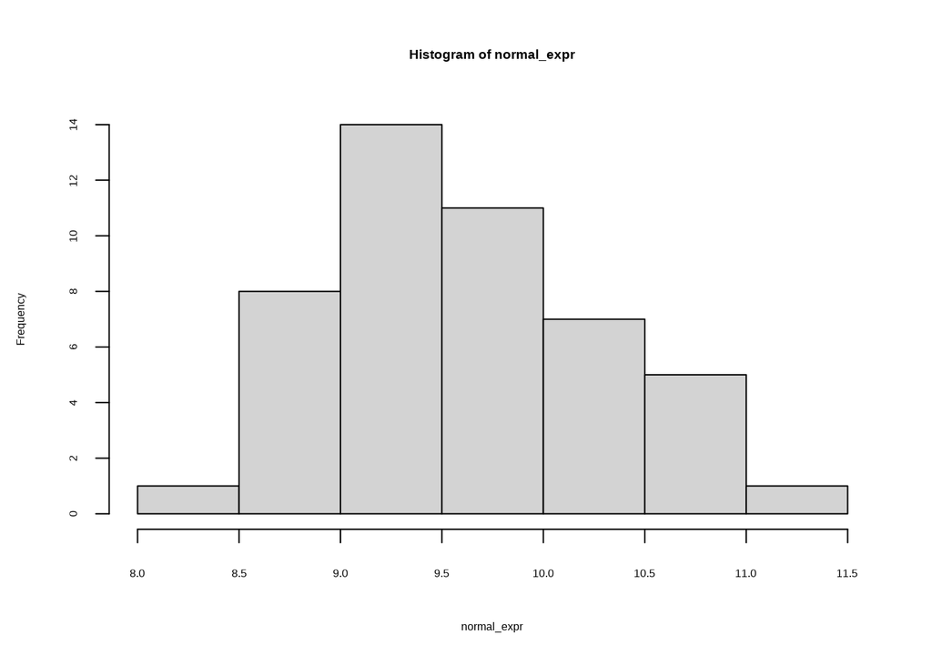

```r
# plot a histogram for control sample with 8 bins
hist(normal_expr, 8)
```

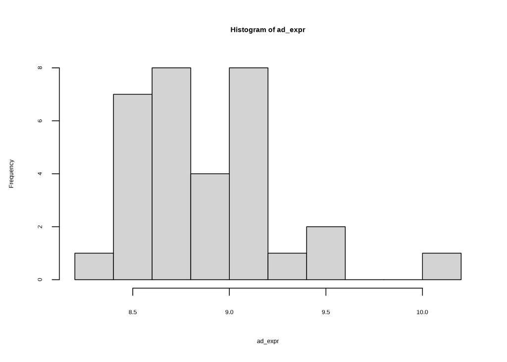

```r
# plot a histogram for control sample with 8 bins
hist(ad_expr, 8)
```

##basic plots

One of the most opular plots of all time is a bar plot. Let’s see how it will represent our data

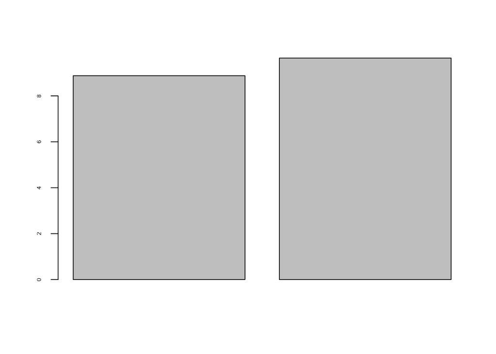

```r
# barplot representing means for both samples
barplot(c(mean(ad_expr), mean(normal_expr)))
```

The plot is difficult to read. Which sample is which? What gene is expressed? can we change it to favourite color?

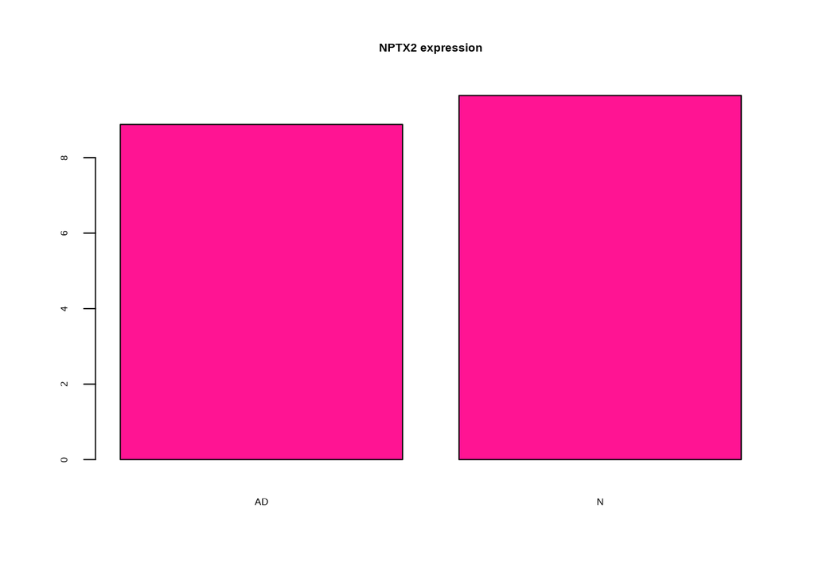

```r
# customised barplot representing means for both samples
barplot(c(mean(ad_expr), mean(normal_expr)),
        main = 'NPTX2 expression',
        names.arg=c('AD', 'N'),
        col = "#FF1493")
```

To choose colors looks for color palettes like this one https://r-charts.com/colors/

The plot is now prettier, but still does not feel very informative. Let’s try box plot

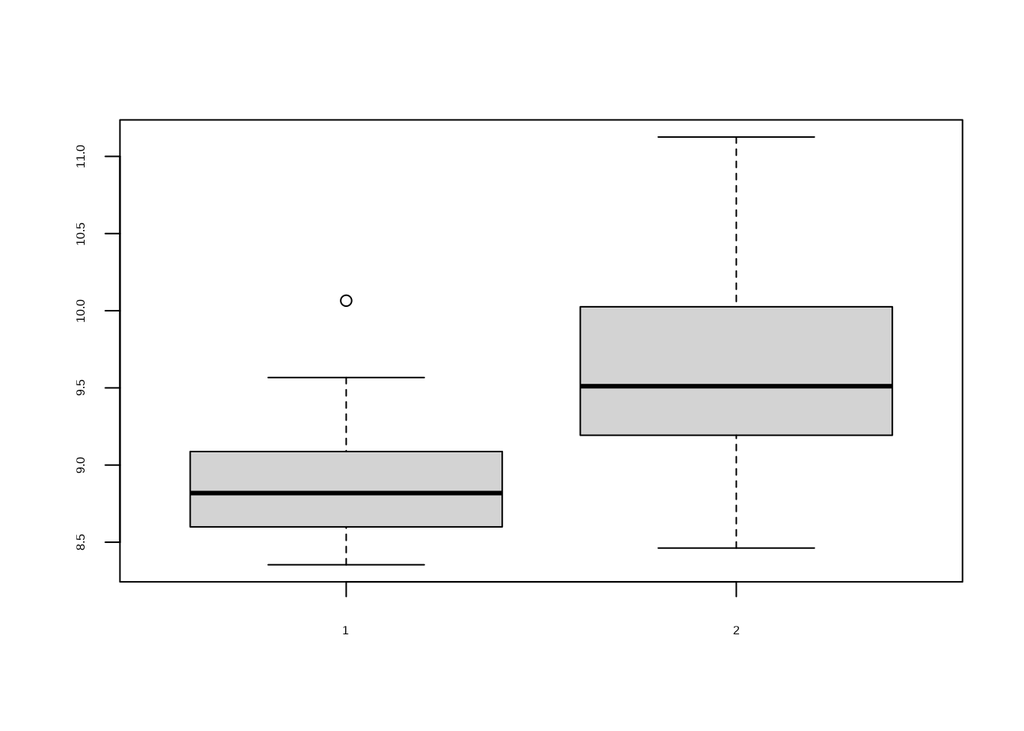

```r
# box plot representing both samples
boxplot(ad_expr, normal_expr)
```

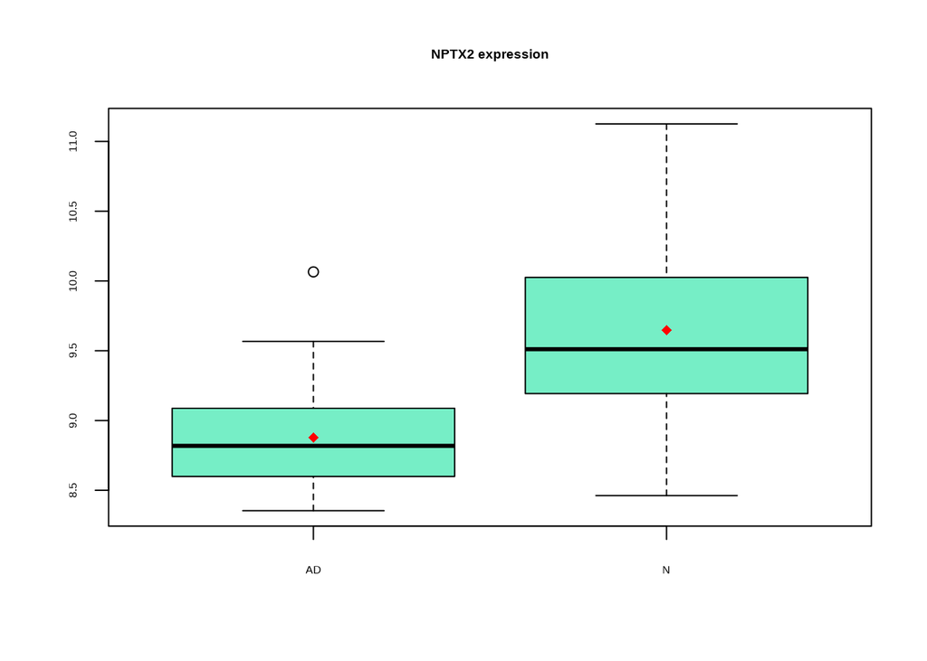

```r
# box plot representing both samples
boxplot(ad_expr, normal_expr, main = 'NPTX2 expression', names=c('AD', 'N'), col = "#76EEC6")
points(c(mean(ad_expr), mean(normal_expr)),col="red",pch=18)
```

##compare 2 genes on scatterplot

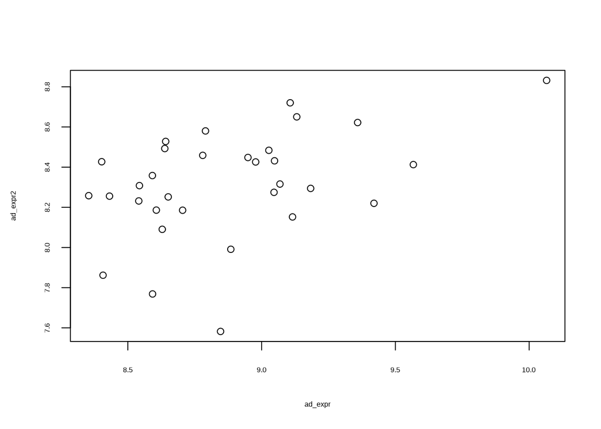

```r
# Show structure of the main data frame (column types, dimensions)
gene_name <- 'LINGO1'

normal_expr2 <-
    df %>%
      filter(Class == 'normal') %>%
      pull(gene_name)

ad_expr2 <-
    df %>%
      filter(Class == 'Alzheimers disease') %>%
      pull(gene_name)

#calculate correlation coefficient and plot a basic scatterplot to see if data is correlated
cor_ad <- cor(ad_expr, ad_expr2)
plot(ad_expr, ad_expr2)
```

##practical assesment Choose a gene from the dataset that was not used in the excercises. Modify the code to pull the data on the expression of this gene in AD and control patient and perform basic analysis as for NPTX2 including comparison between normal and AD patients and testing if there is a significant difference in expression levels.

In case you have trouble with modifying the code, let us know and we’ll help!

As an assessment kindly email following information: 1. name of the gene 2. which test you used for comparison and why 3. p-value 4. are differences between the groups statistically different (use p=0.05 as a cut off)

to: kaja.moczulska@meduniwien.ac.at or lukasz.piszczek@meduniwien.ac.at